# Statistical Inference Course Project

Joshua Chua

Monday, August 17, 2015

# Overview

In this project we investigate the exponential distribution in R and compare it with the Central Limit Theorem. We investigate the distribution of averages of 40 exponentials and illustrate via simulation and associated explanatory text the properties of the distribution of the mean of 40 exponentials.

Include figures (output from R) with titles. Highlight the variances you are comparing. Include text that explains your understanding of the differences of the variances.

# Simulations

The exponential distribution can be simulated in R with rexp(n, lambda) where lambda is the rate parameter. The mean of exponential distribution is 1/lambda and the standard deviation is also 1/lambda. We set lambda = 0.2 for all of the simulations.

```r
#Simulation

#load libraries
library (ggplot2)
library (dplyr)
#set variables
lambda = 0.2 #Set lambda to 0.2
n = 40 #No. of exponentials
sims = 1000 #No. of simulations
set.seed(168931475) #For reproducibility

#generate simulations and calculate means
simulations<-replicate(sims,rexp(n, lambda))
simulation_means<-data.frame(means=apply(simulations, 2, mean))
head(simulation_means)
```

```
##      means
## 1 5.434295
## 2 4.463269
## 3 4.865865
## 4 5.854476
## 5 4.586784
## 6 3.973413
```

# Sample Mean versus Theoretical Mean

## Question 1

1. Show the sample mean and compare it to the theoretical mean of the distribution. The expected (theoretical) mean of an exponential distribution is 1/lambda, in our simulation case this would be 1/0.2 = **5**

From our results we can see that the sample mean of the 1000 simulations is

```r
meanofMeans<-mean(simulation_means$means)
meanofMeans
```

```
## [1] 5.040009
```

which is pretty close to our expected mean.

This histogram plots the simulation data, the line in red is the mean of our simulations and the line in orange is our expected mean, which are pretty close.

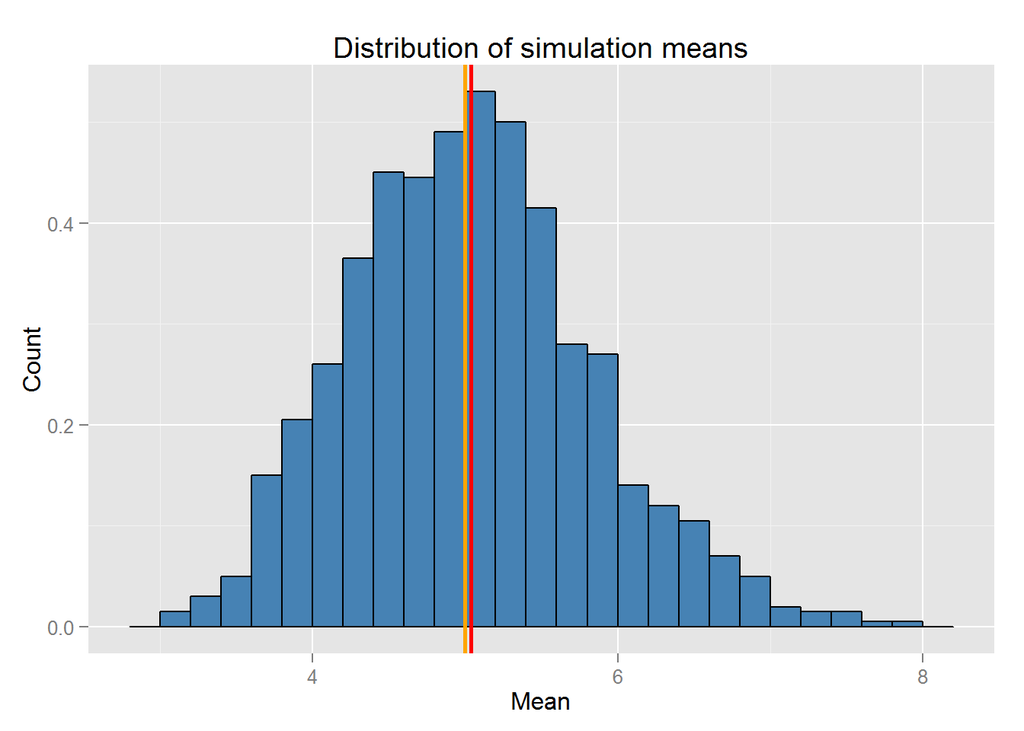

```r
ggplot(simulation_means,aes(x=means)) +
  labs(title="Distribution of simulation means",x="Mean",y="Count")+
  geom_histogram(aes(y=..density..),fill="steelblue",binwidth = 0.2, color = I ("black"))+
  geom_vline(xintercept = 5, color="orange", size=1)+
  geom_vline(xintercept = meanofMeans, color="red", size=1)
```

# Sample Variance versus Theoretical Variance

## Question 2

2. Show how variable the sample is (via variance) and compare it to the theoretical variance of the distribution.

The theoretical variance of our simulation is (1/lambda)*(1/sqrt(n)))^2 = 0.625 Sample variance is

```r
var(simulation_means$means)
```

```
## [1] 0.6197137
```

We can see that the theoretical and sample variance are rather close.

# Distribution

## Question 3

3. Show that the distribution is approximately normal. Plotting the density function of our simulation means, and overlaying it with a normal distribution we can see that the distribution of the simulation means is approximately normal, as the Central Limit Theorem exerts.

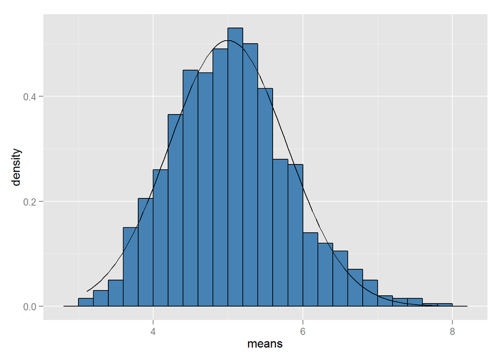

```r
ggplot(simulation_means,aes(x=means)) +
  geom_histogram(aes(y=..density..),fill="steelblue",binwidth = 0.2, color = I("black"))+
#  geom_vline(xintercept = 5, color="orange", size=1)+
#  geom_vline(xintercept = meanofMeans, color="red", size=1)+
  labs(ggtitle="Distribution of simulation means",xlab="Count",ylab="Mean")+
  stat_function(fun = dnorm, arg = list(mean = 5, sd = sd(simulation_means$mean)))
```

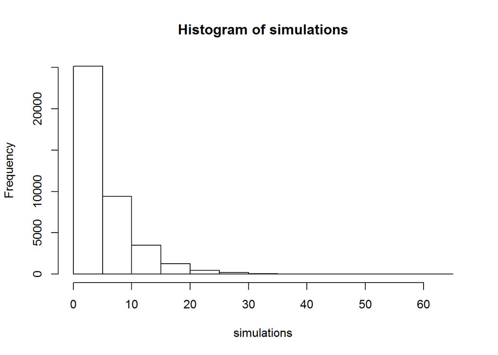

```r
hist(simulations)
```